# Valeurs extrêmes II

Olivier Berthier

2024-07-31

Nous nous intéressons ici à différents jeux de données. Nous n’essayerons pas d’être exhaustif en essayant toutes les méthodes, au contraire nous sélectionnerons celles qui nous paraissent les plus adaptées.

# Dow Jones

```r
data ("dowjones")
dj <- dowjones
str (dj)
```

```
## 'data.frame':    1304 obs. of  2 variables:
##  $ Date : POSIXt, format: "1995-09-11 02:00:00" "1995-09-12 02:00:00" ...
##  $ Index: num  4705 4747 4766 4802 4798 ...
```

Le jeu de données contient 1304 observations sur 2 variables: la date et le prix à la fermeture de l’indice Down Jones sur 5 ans de septembre 1995 à septembre 2000.

Plot avant stationnarisation:

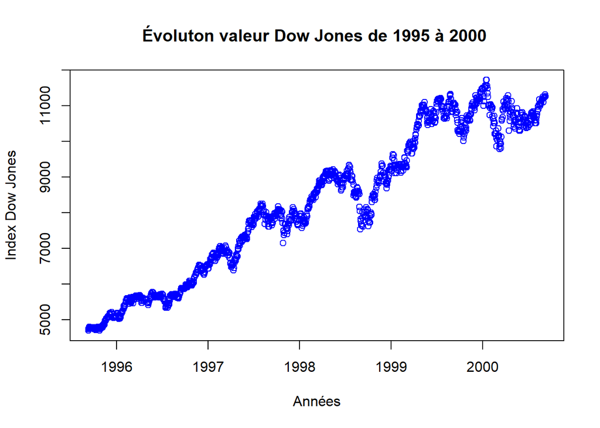

L’hypothèse d’une variable *iid* n’est évidemment pas vérifiée ici, nous devons stationnariser la série.

Stationnarisation selon les indications de l’énoncé:

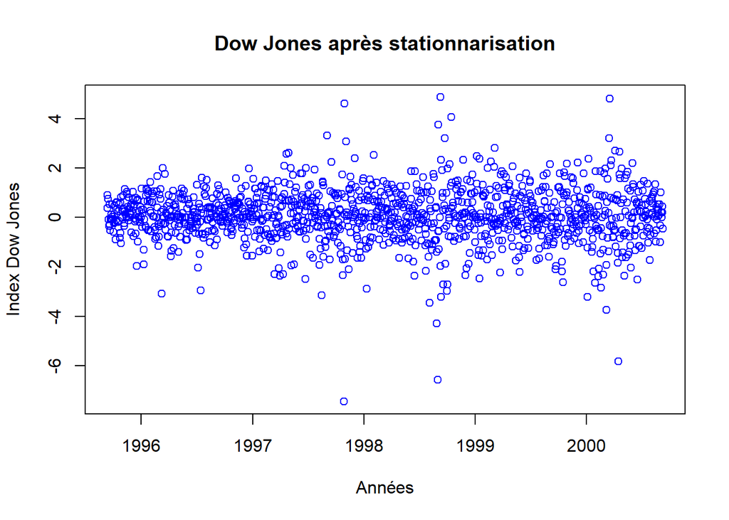

```r
djsta <- dj %>%
  mutate(ind = 100 * (log(Index) - log(lag(Index)))) %>%
  na.omit() %>%  # Supprimer la première ligne de valeur NA suite à la transformation
  select(-Index)  # Supprimer la variable Index
plot (djsta, col ="blue", ylab="Index Dow Jones", xlab = "Années", main = "Dow Jones après stationnarisation")
```

La stationnarisation est de bonne qualité.

```
##       Date                          ind
##  Min.   :1995-09-12 02:00:00   Min.   :-7.45491
##  1st Qu.:1996-12-10 13:00:00   1st Qu.:-0.47792
##  Median :1998-03-11 01:00:00   Median : 0.05380
##  Mean   :1998-03-11 01:00:00   Mean   : 0.06697
##  3rd Qu.:1999-06-09 14:00:00   3rd Qu.: 0.67781
##  Max.   :2000-09-07 02:00:00   Max.   : 4.86053
```

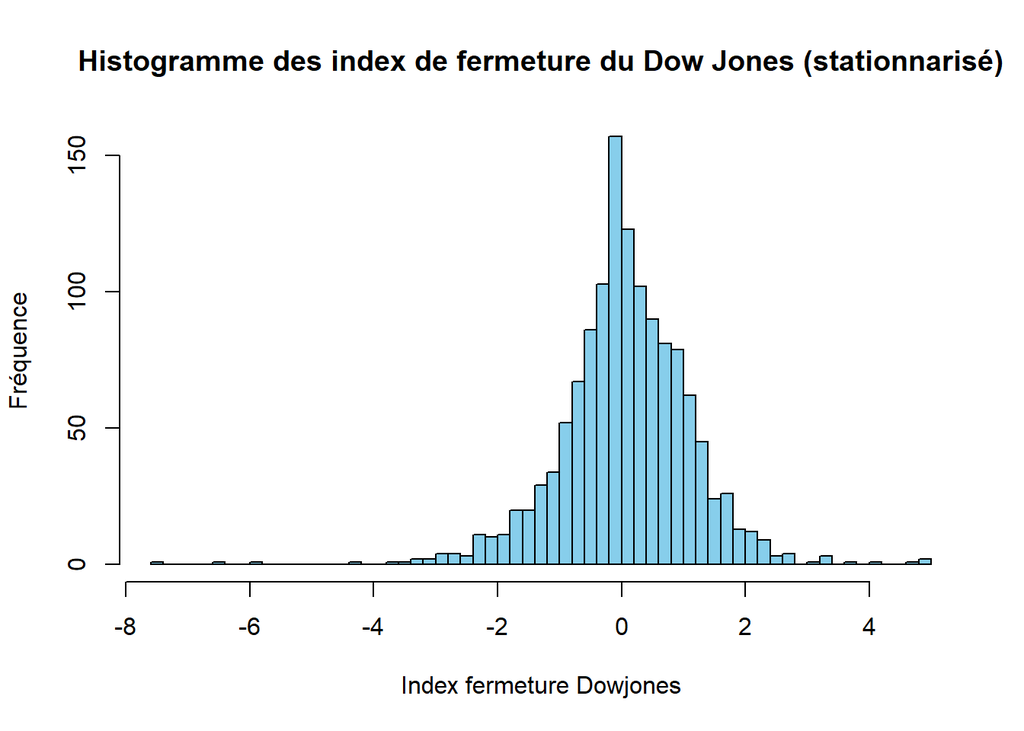

Comme espéré, la queue de la distribution est nettement plus longue que dans le cas des températures à Fort Collins, nous pouvons donc envisager un domaine d’attraction de *Fréchet*.

Les données ne s’étalant que sur 5 années, nous privilégions une approche par seuil. Une approche par **block maxima**, si elle n’est pas impossible (par exemple en retenant le maximum par mois), ne semble pas indiquée notamment pour les raisons suivante:

- La bourse est fermée le weekend, le nombre d’observations n’est pas identique tous les mois;
- Même remarque concernant les jours fériés;
- Impossible d’évacuer totalement le risque de saisonnalité (moins d’activité pendant l’été ou les fêtes de fin d’année par exemple).

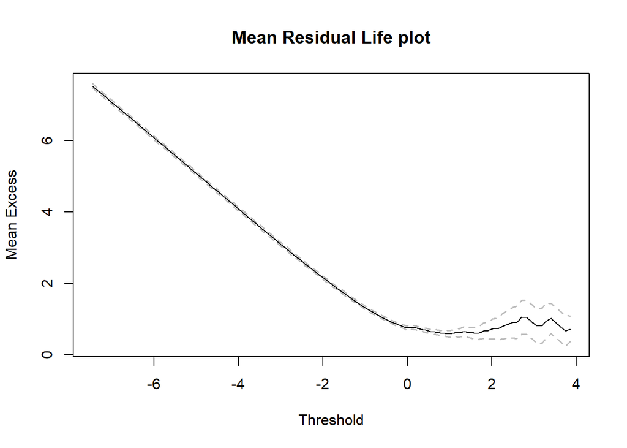

Intéressons-nous aux valeurs autour de *2*.

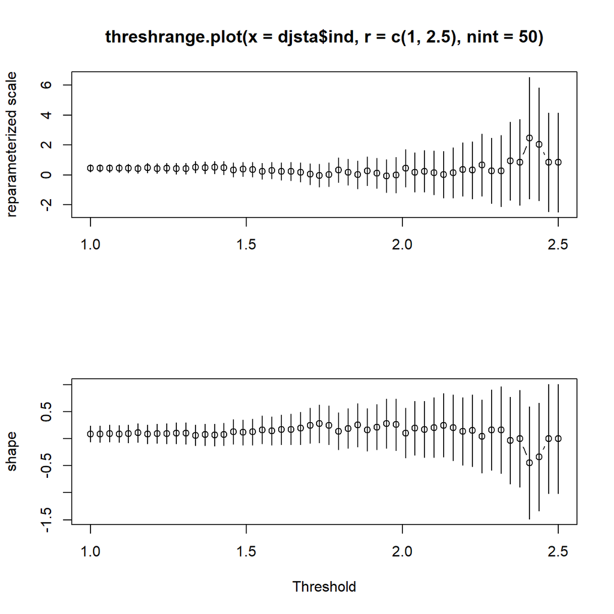

*2* semble en effet une bonne valeur de seuil.

```
## [1] 37
```

```
## [1] 0.02839601
```

37 valeurs sont retenues avec le seuil de *2*, soit environ 3% des observations initiales.

## MLE

```r
Fit_dj_GPD_MLE_2=fevd(djsta$ind,threshold=2, type="GP",method="MLE", span = 1000,time.units="250/year")
Fit_dj_GPD_MLE_2
```

```
##
## fevd(x = djsta$ind, threshold = 2, type = "GP", method = "MLE",
##     span = 1000, time.units = "250/year")
##
## [1] "Estimation Method used: MLE"
##
##
##  Negative Log-Likelihood Value:  21.64016
##
##
##  Estimated parameters:
##     scale     shape
## 0.4951160 0.2878324
##
##  Standard Error Estimates:
##     scale     shape
## 0.1495613 0.2578010
##
##  Estimated parameter covariance matrix.
##             scale       shape
## scale  0.02236858 -0.02794575
## shape -0.02794575  0.06646138
##
##  AIC = 47.28031
##
##  BIC = 50.50215
```

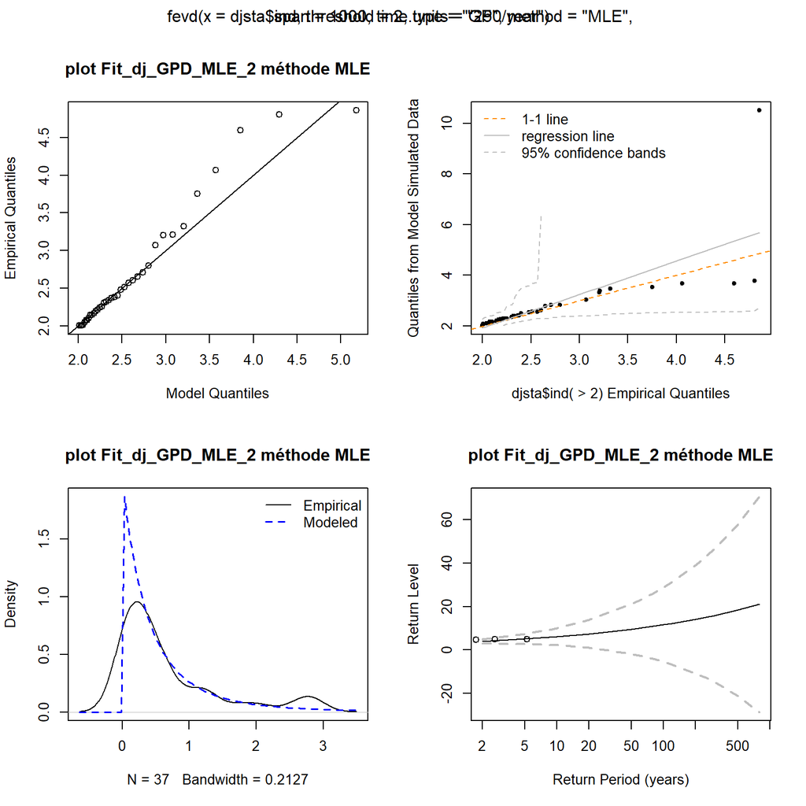

```r
plot (Fit_dj_GPD_MLE_2, main = "plot Fit_dj_GPD_MLE_2 méthode MLE")
```

# PWM

```r
Fit_dj_GPD_PWM_2=fevd(djsta$ind,threshold=2,type="GP", method="Lmoments",time.units="250/year")
Fit_dj_GPD_PWM_2
```

```
## fevd(x = djsta$ind, threshold = 2, type = "GP", method = "Lmoments",
##     time.units = "250/year")
## [1] "GP  Fitted to  djsta$ind  using L-moments estimation."
##     scale     shape
## 0.4663051 0.3094726
```

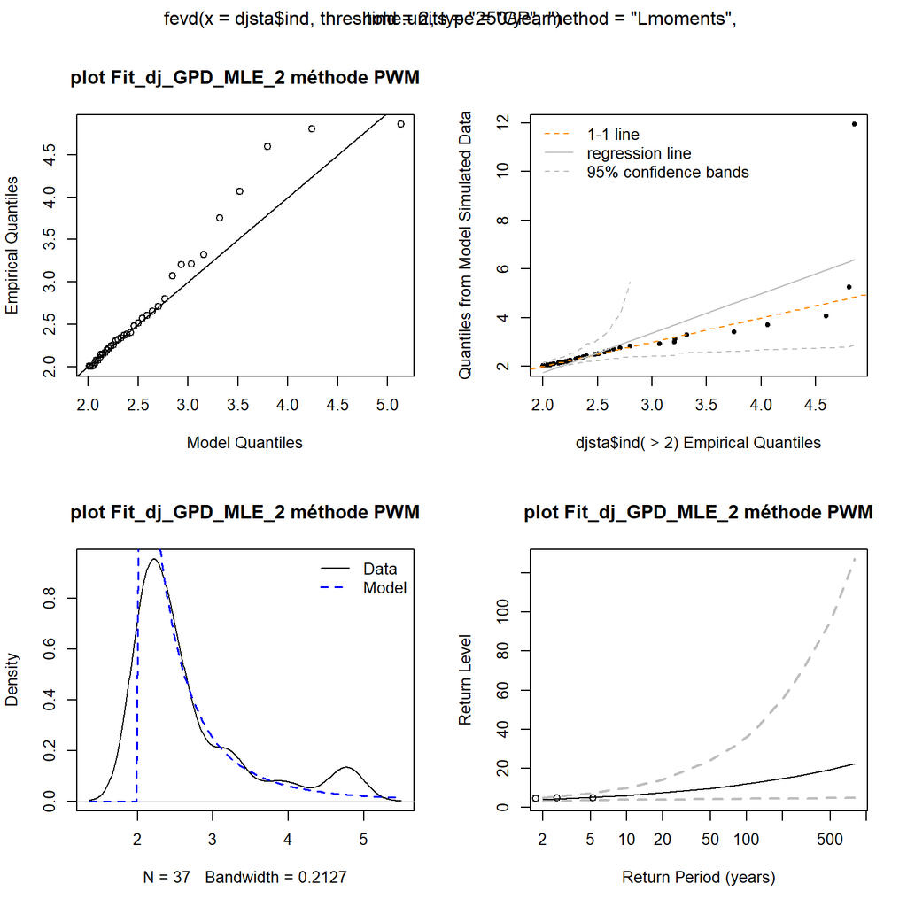

```r
plot (Fit_dj_GPD_PWM_2, main = "plot Fit_dj_GPD_MLE_2 méthode PWM")
```

## Comparaison

La modélisation est acceptable pour les deux modèles, notons que la forme particulière de la distribution empirique (graphique 3) n’est pas facile à modéliser.

Regardons en détails les *return plot* des deux modèles:

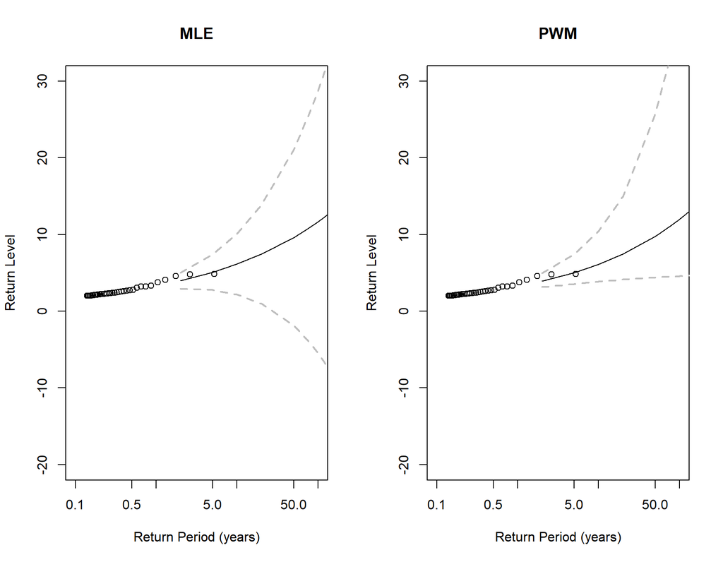

L’intervalle de confiance par la méthode **PWM** est plus resserré (nombre d’observations sans doute trop faible pour la MLE).

## Niveaux de retour

```r
return.level(Fit_dj_GPD_MLE_2, return.period = c(10, 20, 100))
```

```
## fevd(x = djsta$ind, threshold = 2, type = "GP", method = "MLE",
##     span = 1000, time.units = "250/year")
## get(paste("return.level.fevd.", newcl, sep = ""))(x = x, return.period = return.period)
##
##  GP model fitted to  djsta$ind
## Data are assumed to be  stationary
## [1] "Return Levels for period units in years"
##  10-year level  20-year level 100-year level
##       6.146653       7.442071      11.662255
```

```r
return.level(Fit_dj_GPD_PWM_2, return.period = c(10, 20, 100))
```

```
## fevd(x = djsta$ind, threshold = 2, type = "GP", method = "Lmoments",
##     time.units = "250/year")
## get(paste("return.level.fevd.", newcl, sep = ""))(x = x, return.period = return.period)
##
##  GP model fitted to  djsta$ind
## Data are assumed to be  stationary
## [1] "Return Levels for period units in years"
##  10-year level  20-year level 100-year level
##       6.128860       7.477211      11.985748
```

À l’horizon de 10 ans, la valeur maximale dépassée en moyenne 1 fois est de *6.15* selon la méthode MLE et *6.13* selon la méthode PWM, à comparer à *4.86*, valeur maximale de nos données stionnarisées.

Calculons les niveaux de retour dans l’unité d’origine (avant staionnarisation) pour la méthode PWM:

```r
return_periods <- c(10, 20, 100)
return_levels <- return.level(Fit_dj_GPD_PWM_2, return.period = return_periods)
# Transformation des niveaux de retour en unités d'origine en utilisant la dernière valeur "Index" du dataframe d'origine
ref <- tail(dj$Index, 1)
return_levels_original <- ref * exp(return_levels / 100) # transformation inverse
print(return_levels_original)
```

```
## fevd(x = djsta$ind, threshold = 2, type = "GP", method = "Lmoments",
##     time.units = "250/year")
## get(paste("return.level.fevd.", newcl, sep = ""))(x = x, return.period = return.period)
##
##  GP model fitted to  djsta$ind
## Data are assumed to be  stationary
## [1] "Return Levels for period units in years"
##  10-year level  20-year level 100-year level
##       11971.56       12134.07       12693.66
```

Les niveaux de retour *dé-stationnarisés* sont à prendre avec beaoucoup de précautions, la modélisation de la tendance étant ici rudimentaire.

# Port Pirie

Ce jeu de données contient le niveau de la mer maximal par année mesuré à Port Pirie (Adelaide, Australie), de 1923 à 1987, soit 65 observations.

```r
data ("portpirie")
pp <- portpirie
```

*Summary* et histogramme de la variable des maximums de niveau d’eau:

```
##       Year         SeaLevel
##  Min.   :1923   Min.   :3.570
##  1st Qu.:1939   1st Qu.:3.830
##  Median :1955   Median :3.960
##  Mean   :1955   Mean   :3.981
##  3rd Qu.:1971   3rd Qu.:4.110
##  Max.   :1987   Max.   :4.690
```

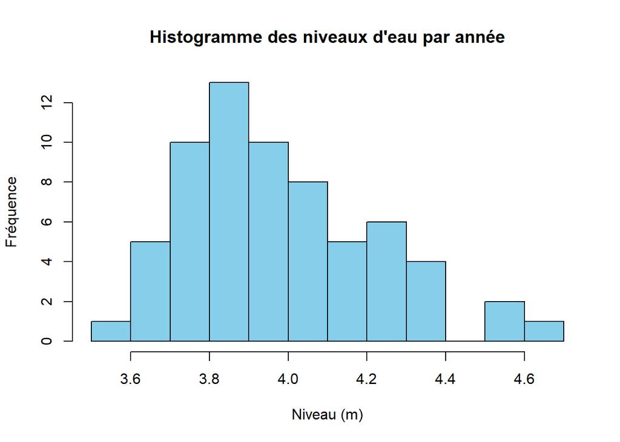

Les données sont déjà des maximums annuels, ici seul la GEV sera donc applicable.

L’unité n’est pas précisée mais nous pouvons supposer que la hauteur d’eau est mesurée en mètres. L’histogramme montre une ditribution proche d’une loi normale à asymétrie positive (moyenne supérieure à la médiane).

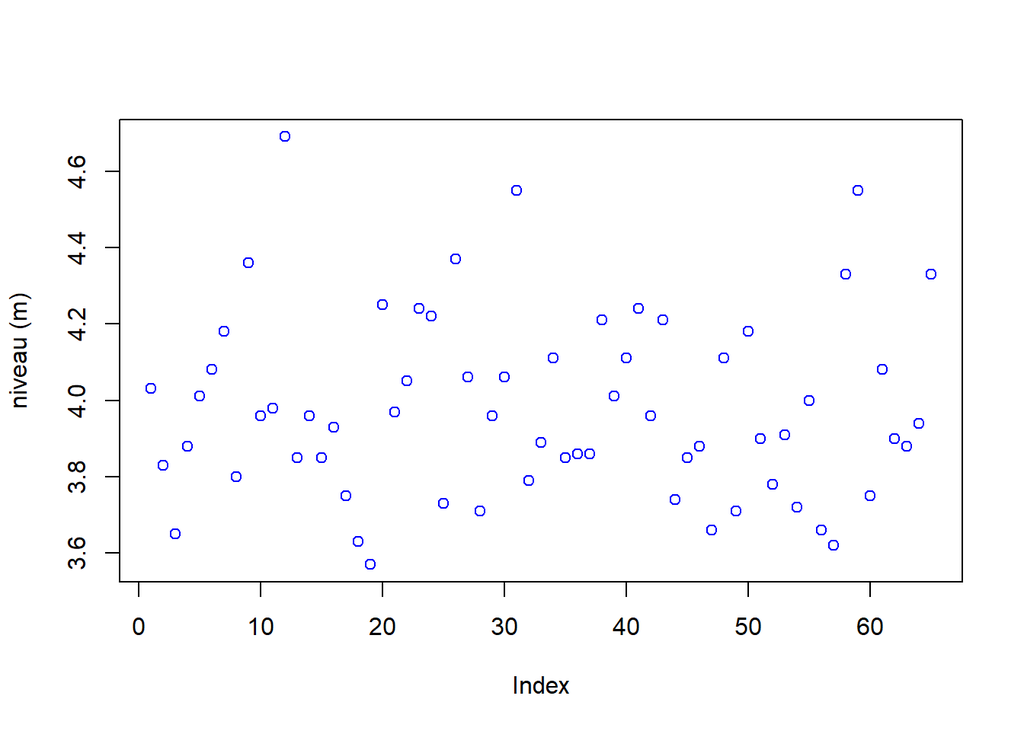

```r
plot (pp$SeaLevel, ylab = "niveau (m)",col = "blue")
```

Les observations semblent *iid*: nous ne discernons pas vraiment de *pattern* sur la période concernée.

```r
Fit_pp_MLE <- fevd(pp$SeaLevel,type="GEV",method="MLE")
Fit_pp_MLE
```

```
##
## fevd(x = pp$SeaLevel, type = "GEV", method = "MLE")
##
## [1] "Estimation Method used: MLE"
##
##
##  Negative Log-Likelihood Value:  -4.339058
##
##
##  Estimated parameters:
##   location      scale      shape
##  3.8747499  0.1980440 -0.0501095
##
##  Standard Error Estimates:
##   location      scale      shape
## 0.02793224 0.02024798 0.09825416
##
##  Estimated parameter covariance matrix.
##               location         scale         shape
## location  0.0007802099  0.0001970436 -0.0010740750
## scale     0.0001970436  0.0004099808 -0.0007774225
## shape    -0.0010740750 -0.0007774225  0.0096538796
##
##  AIC = -2.678117
##
##  BIC = 3.845045
```

```r
ci(Fit_pp_MLE,type="parameter")           # IC à 95%
```

```
## fevd(x = pp$SeaLevel, type = "GEV", method = "MLE")
##
## [1] "Normal Approx."
##
##          95% lower CI   Estimate 95% upper CI
## location    3.8200037  3.8747499    3.9294960
## scale       0.1583586  0.1980440    0.2377293
## shape      -0.2426841 -0.0501095    0.1424651
```

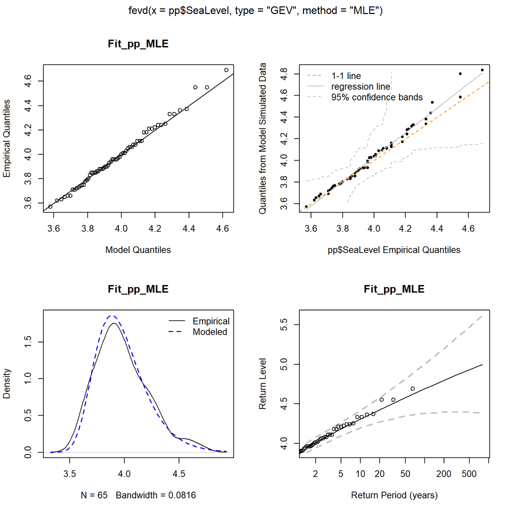

```r
plot(Fit_pp_MLE, main= "Fit_pp_MLE")
```

La modélisation est de bonne qualité.  
le $\gamma$ est très proche de zéro et l’intervalle de confiance à 95% inclut zéro. Une modélisation en forçant *Gumbel* semble indiquée.

Remarque: nous n’essayerons pas ici de modélisation utilisant la méthode PWM, la modélisation MLE fonctionne correctement et nous ne pouvons pas “forcer” *Gumbel* en PWM (avec ce package).

```r
Fit_pp_MLE_G <- fevd(pp$SeaLevel,  type="Gumbel",method="MLE")
Fit_pp_MLE_G
```

```
##
## fevd(x = pp$SeaLevel, type = "Gumbel", method = "MLE")
##
## [1] "Estimation Method used: MLE"
##
##
##  Negative Log-Likelihood Value:  -4.217682
##
##
##  Estimated parameters:
##  location     scale
## 3.8694436 0.1948895
##
##  Standard Error Estimates:
##   location      scale
## 0.02549389 0.01885368
##
##  Estimated parameter covariance matrix.
##              location        scale
## location 0.0006499383 0.0001527080
## scale    0.0001527080 0.0003554611
##
##  AIC = -4.435364
##
##  BIC = -0.08658925
```

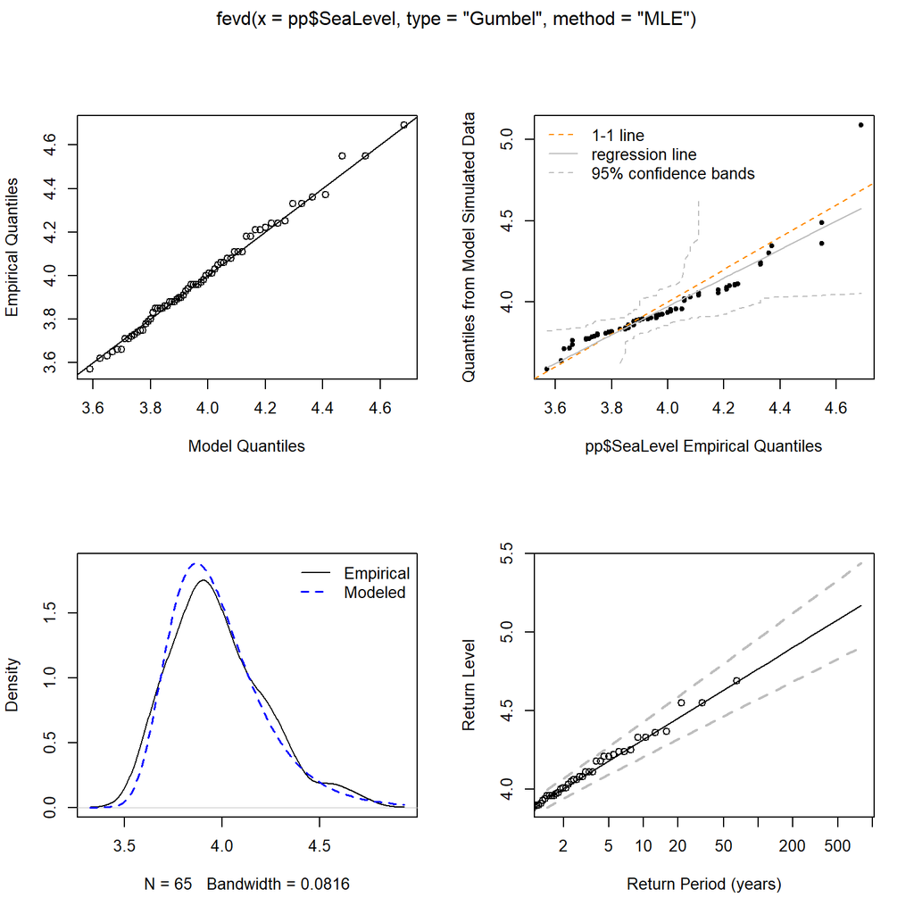

```r
plot(Fit_pp_MLE_G)
```

Les AIC et BIC sont meilleurs en forçant une loi de *Gumbel* Les graphiques semblent aussi indiquer une meilleure modélisation.

Nous retenons donc **Fit_pp_MLE_G** pour le calcul des niveaux de retour.

```r
return.level(Fit_pp_MLE_G, return.period = c(100, 1000))
```

```
## fevd(x = pp$SeaLevel, type = "Gumbel", method = "MLE")
## get(paste("return.level.fevd.", newcl, sep = ""))(x = x, return.period = return.period)
##
##  Gumbel model fitted to  pp$SeaLevel
## Data are assumed to be  stationary
## [1] "Return Levels for period units in years"
##  100-year level 1000-year level
##        4.765964        5.215595
```

Nous pouvons conclure que le niveau maximal atteint en moyenne une fois tous les 100 ans est de *4.77m* et de *5.22m* à l’horizon de 1000 ans, donc peu au-dessus du niveau maximal de nos données (*4.69m*).

# Temps aux 100m

Importation des données et transformation selon indications:

```r
temps100m <- read_csv("C:/Users/olivi/Downloads/temps100m.csv")
time <- sort(temps100m$temps,decreasing=TRUE) # pour ordonner les données.
vit <- 360/time
summary (vit)
```

```
##    Min. 1st Qu.  Median    Mean 3rd Qu.    Max.
##   34.93   35.08   35.31   35.45   35.74   37.58
```

Les vitesses moyennes aux 100m s’étalent de 34.93 km/h à 37.58km/h.  
Le coureur étant à l’arret au départ de la course, il dépasse évodemment en vitesse de pointe ces valeurs.

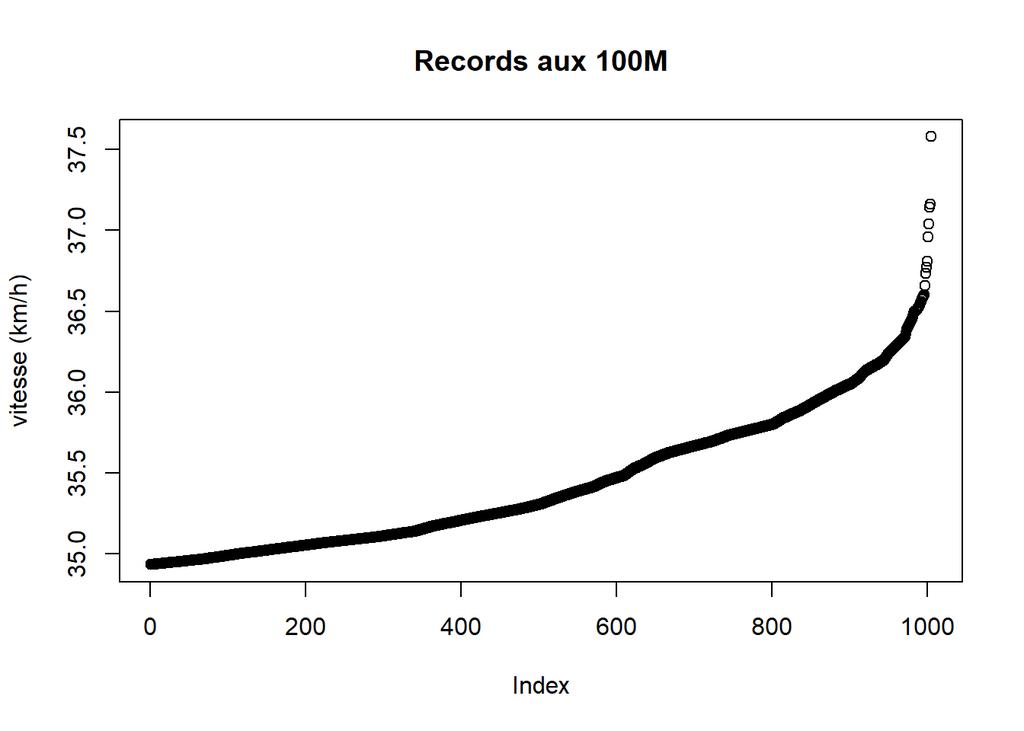

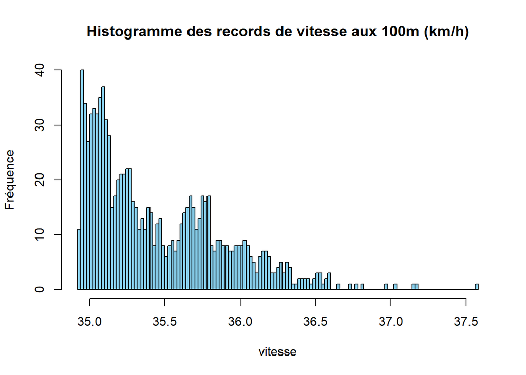

Une seule valeur apparait comme étant très au dessus des autres, le temps d’Usan Bolt.

Détermination du seuil:

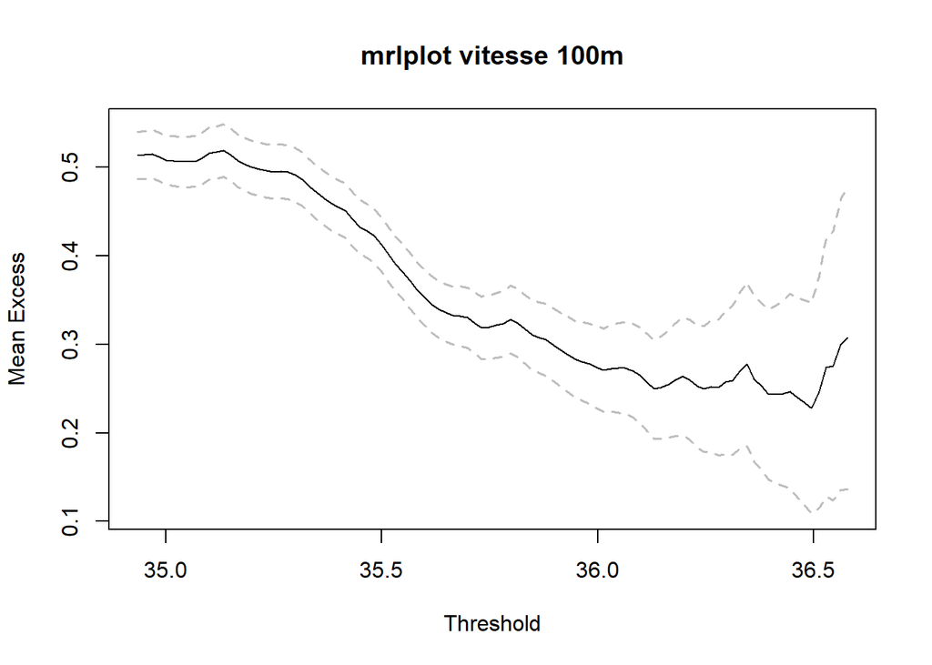

```r
mrlplot (vit, main= "mrlplot vitesse 100m")
```

Considérons en détails les valeurs autour de 36km/h:

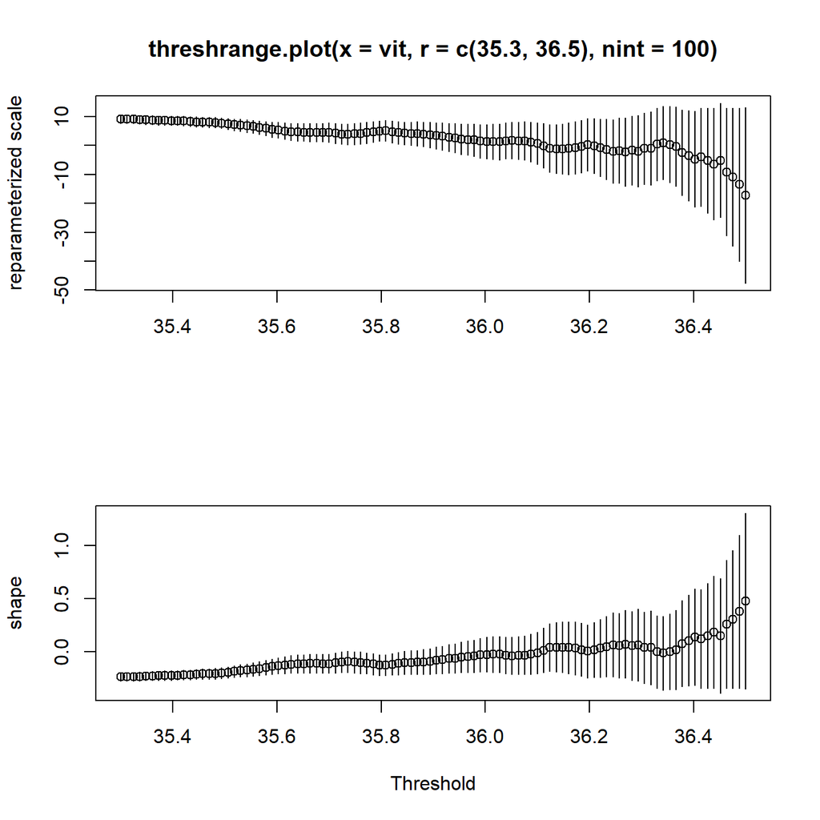

```r
threshrange.plot(vit, r = c(35.3, 36.5), nint=100)
```

Aucun seuil ne s’impose de manière évidente.  
En considérant l’histogramme, le **mrlplot** et le *Threshold Stability plot*, *36km/h* semble offrir un bon compromis.

Proposition: pour sélectionner précisément le seuil, nous allons considérer le record d’Usan Bolt comme une valeur possible (de fait, elle l’est) mais qui se situerait aux limites à 95% du modèle.  
En effet, son record correspond presque à une anomalie statistique, tellement il surpasse les autres temps.

Nous n’utiliserons ici que la méthode *MLE* afin de ne pas surcharger le rapport (le nombre d’observations est suffisant et les intervalles de confiance sont plus robustes avec cette méthode).

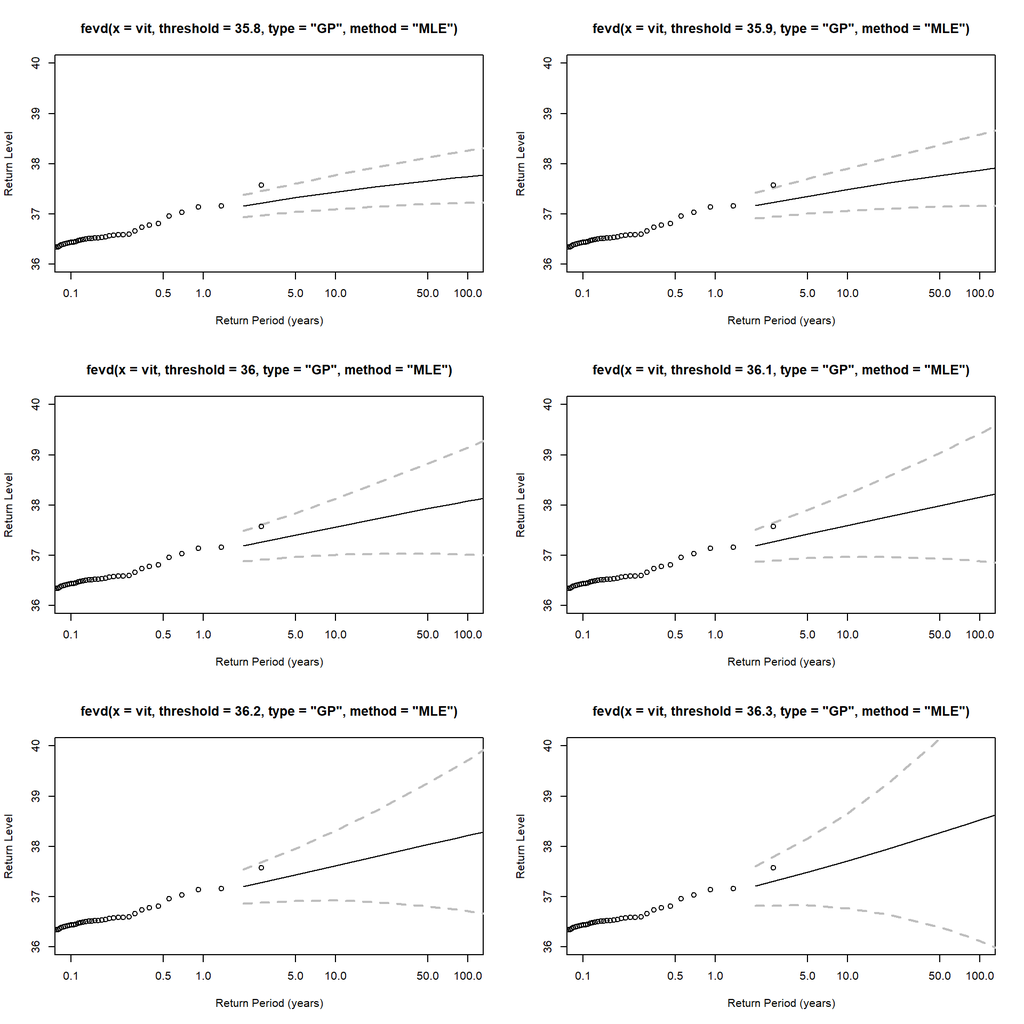

La valeur seuil de 36km/h permet une modélisation qui contient à la limite de l’intervalle de confiance à 95% le record d’Usan Bolt.  
Nous retenons cette valeur.

126 observations sont conservées, soit environ 12% du total.

```r
Fit_vit_GPD_MLE_36
```

```
##
## fevd(x = vit, threshold = 36, type = "GP", method = "MLE")
##
## [1] "Estimation Method used: MLE"
##
##
##  Negative Log-Likelihood Value:  -37.38556
##
##
##  Estimated parameters:
##      scale      shape
##  0.2825705 -0.0328833
##
##  Standard Error Estimates:
##      scale      shape
## 0.03430347 0.08252486
##
##  Estimated parameter covariance matrix.
##              scale        shape
## scale  0.001176728 -0.001995694
## shape -0.001995694  0.006810353
##
##  AIC = -70.77112
##
##  BIC = -65.09856
```

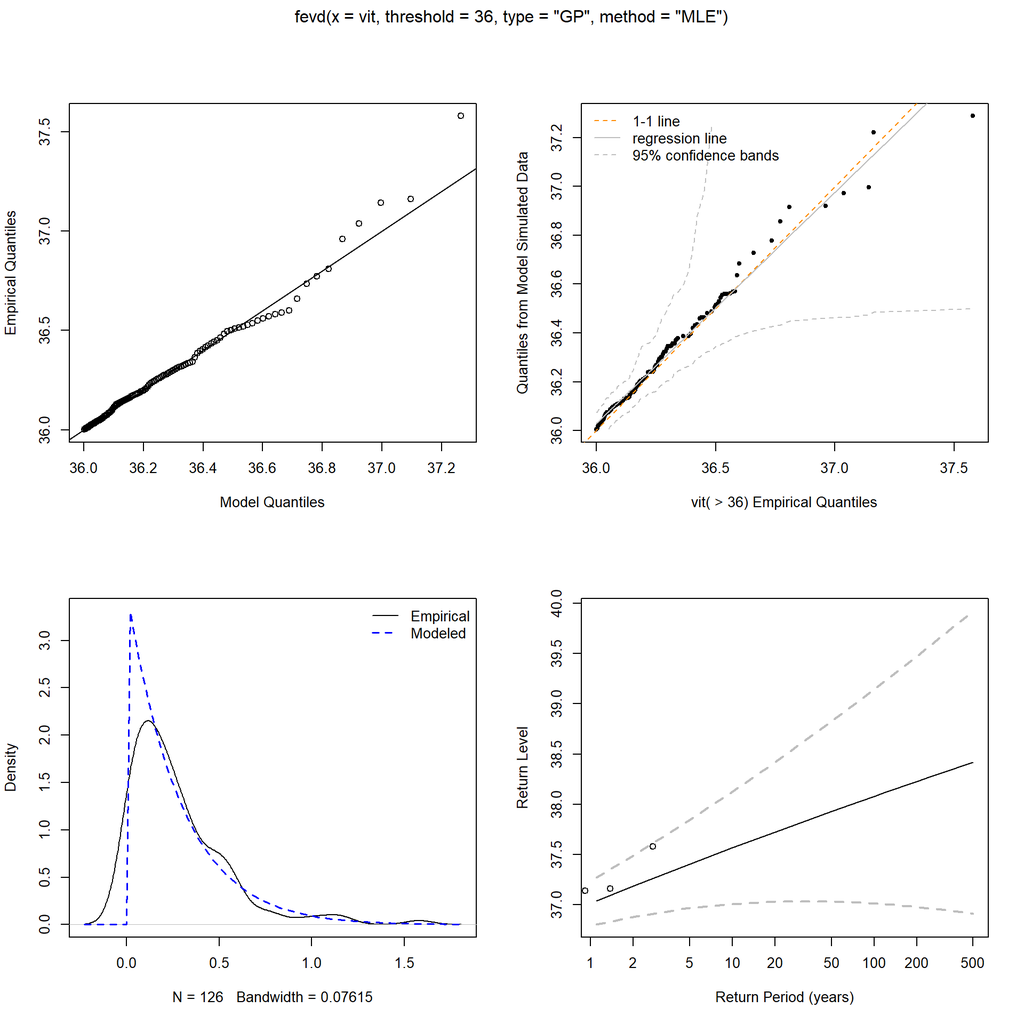

```r
plot (Fit_vit_GPD_MLE_36, period ="events", rperiods = c(1.1, 2, 5, 10, 20, 50, 80, 100, 120, 200, 250, 300, 500))
```

La modélisation est acceptable.  
Le domaine d’attraction est celui de *Weibull*.

```r
360 / (36 -(0.2825705 /-0.0328833))
```

```
## [1] 8.072992
```

Le point terminal correspond à un temps de 8.07s aux 100m.